# Homework #1 Answers

## Chongye Feng

```python
from pylab import *
from mpl_toolkits.mplot3d import Axes3D
import numpy as np
%matplotlib inline
```

```python
import time

def timeit(f):

    def timed(*args, **kw):

        ts = time.time()
        result = f(*args, **kw)
        te = time.time()

        print('func:%r took: %2.4f sec' % (f.__name__,  te-ts))
        return result

    return timed
```

### Q_1

- a: because it increases the chance of finding the minimum value of the function by evenly dividing the larger interval in half. This allows for a more thorough search of the potential minimum in comparison to only searching a portion of the interval. Additionally, bisecting the larger interval also reduces the overall size of the interval, making it easier to converge towards the minimum value.
- b:
  - If point e is placed in [a,b]:
    1. if f(e) > f(b), we could reduce the interval length from 0.75 to 0.5, a 1/3 reduction;
    2. if f(e) < f(b), we could reduce the interval length from 0.75 to 0.5, a 1/3 reduction;
    3. The average reduction would be 1/3.
  - If point e is placed in [b,d]:
    1. if f(e) > f(b), we could reduce the interval length from 0.75 to 0.625, a 1/6 reduction;
    2. if f(e) < f(b), we could reduce the interval length from 0.75 to 0.25, a 1/2 reduction;
    3. The average reduction would be 1/3.
- c: after step 2, the new interval would be, if e is placed in [a,b], [a,e,b] or [e,b,d] in the size of 0.5. And both of the oiginal bisection point is in the center of the interval, which is in a similar situation of step 1. Take [a,e,b] as an example, both [a,e] and [e,b] are in the same size and no difference without searching:
  - if f is in [a,e], f=0.125;
  - if f is in [e,b], f=0.375;
  - after getting f, the new reduced interval would be in size 0.25 or 0.375;
- d:

  ```
           1/2                 3/4
           / \                 / \
       1/2     3/4         2/3     2/3
       / \     / \         / \     / \
    1/2  3/4 2/3  2/3   1/2  3/4 1/2  3/4
  ```

- e:

```python
# step 1
(0.5 + 0.75) / 2
```

```
0.625
```

```python
# step 2
(0.5 + 0.75 + 4/3) / 4
```

```
0.6458333333333333
```

```python
# step 3
((0.5 + 0.75) * 3 + 4/3) / 8
```

```
0.6354166666666666
```

- f: For Golden Section, the ratio of size of interval of the previous step is 0.618, no change.

  ```
              0.618                       0.618
             /     \                     /     \
       0.618        0.618          0.618        0.618
        / \          / \            / \          / \
   0.618   0.618 0.618  0.618  0.618   0.618 0.618  0.618
  ```

  Comparing with bisection:

  ```
   Method: Bisection   Golden Section    Diff

   1:      0.625       0.618             0.007

   2:      0.646       0.618             0.028

   3:      0.635       0.618             0.017
  ```

It shows that Golden Section is reducing more searching interval than Bisection method.

### Q_2

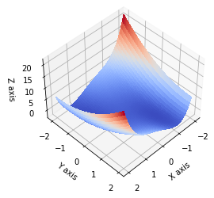

```python
def func_q2(coord):
    x = coord[0]
    y = coord[1]
    return x**4 - x**2 + y**2 + 2*x*y -2

x = np.linspace(-2, 2, 200)
y = np.linspace(-2, 2, 200)
X, Y = np.meshgrid(x, y)
Z = func_q2((X, Y))

fig = plt.figure()
ax = fig.add_subplot(111, projection='3d')
ax.plot_surface(X, Y, Z, cmap=cm.coolwarm, linewidth=0, antialiased=False)
ax.set_xlabel('X axis')
ax.set_ylabel('Y axis')
ax.set_zlabel('Z axis')
ax.view_init(45,45)
plt.show()
```

- a:

```python
Z
```

```
array([[22.        , 21.36601181, 20.75022147, ...,  5.07182951,
         5.52681583,  6.        ],
       [21.83960001, 21.20641988, 20.5914376 , ...,  5.07061742,
         5.5264118 ,  6.00040403],
       [21.68000808, 21.04763601, 20.43346179, ...,  5.07021339,
         5.52681583,  6.00161612],
       ...,
       [ 6.00161612,  5.52681583,  5.07021339, ..., 20.43346179,
        21.04763601, 21.68000808],
       [ 6.00040403,  5.5264118 ,  5.07061742, ..., 20.5914376 ,
        21.20641988, 21.83960001],
       [ 6.        ,  5.52681583,  5.07182951, ..., 20.75022147,
        21.36601181, 22.        ]])
```

```python
# point f(1.5,1.5)
func_q2((1.5,1.5))
```

```
7.5625
```

```python
def first_derivate_q2(coord):
    x = coord[0]
    y = coord[1]
    dx = 4 * x**3 - 2 * x + 2 * y
    dy = 2 * y + 2 * x
    return (dx, dy)
```

```python
first_derivate_q2((1.5,1.5))
```

```
(13.5, 6.0)
```

So, the first step would be 0.1 * (13.5, 6), which is (1.35, 0.6).

And the x_0 (1.5, 1.5) with the limit is ([-2,2], [-2,2]).

So, the x_1 would be (1.5 - 1.35, 1.5 - 0.6), which is (0.15, 0.90).

To judge if it is a good step:

```python
func_q2((0.15,0.9)) < func_q2((1.5,1.5))
```

```
True
```

f(x_1) < f(x_0)

So that it is a good step.

Based on this outcome, the step size would be increased to (0.12 * first_derivative(x,y)). And, the start point would be updated to x_1 (0.15, 0.90).

- b:

```python
from pylab import *
import numpy.linalg as LA

@timeit
def steepest_descent(func, first_derivate, starting_point, stepsize, tol):
    # evaluate the gradient at starting point
    deriv = first_derivate(starting_point)
    count = 0
    visited = []

    while LA.norm(deriv) > tol and count < 1e6:
        # calculate new point position
        new_x = starting_point[0] - stepsize * deriv[0]
        new_y = starting_point[1] - stepsize * deriv[1]

        new_point = (new_x,new_y)
        visited.append(new_point)

        if func(new_point) < func(starting_point):
            # the step makes function evaluation lower - it is a good step. what do you do?
            starting_point = new_point
            deriv = first_derivate(starting_point)
            stepsize *= 1.2
            count += 1
        else:
            # the step makes function evaluation higher - it is a bad step. what do you do?
            stepsize *= 0.5

    # return the results
    return {"x": starting_point, "evaluation": func(starting_point), "n_steps": count}
```

```python
steepest_descent(func_q2,first_derivate_q2,(1.5,1.5),0.1,1e-5)
```

```
func:'steepest_descent' took: 0.0007 sec
```

```
{'x': (-0.999998515461034, 0.9999960662218339),
 'evaluation': -2.999999999985186,
 'n_steps': 41}
```

In my case, the method took 41 steps, from step 1, to converge to point (-0.999998515461034, 0.9999960662218339) with an evaluation of -2.999999999985186. It tooks 0.0007 second.

- c:

```python
from scipy.optimize import minimize
```

```python
@timeit
def timming_BFGS():
    res = minimize(func_q2, (1.5,1.5), method='BFGS', options={'disp': True, 'gtol': 1e-5})

    print("Minimum of the function:", res.fun)
    print("Location of the minimum:", res.x)

timming_BFGS()
```

```
Optimization terminated successfully.
         Current function value: -3.000000
         Iterations: 7
         Function evaluations: 24
         Gradient evaluations: 8
Minimum of the function: -2.9999999999998255
Location of the minimum: [ 0.99999979 -0.9999998 ]
func:'timming_BFGS' took: 0.0030 sec
```

```python
@timeit
def timming_CG():
    res = minimize(func_q2, (1.5,1.5), method='CG', options={'disp': True, 'gtol': 1e-5})

    print("Minimum of the function:", res.fun)
    print("Location of the minimum:", res.x)

timming_CG()
```

```
Optimization terminated successfully.
         Current function value: -3.000000
         Iterations: 9
         Function evaluations: 78
         Gradient evaluations: 26
Minimum of the function: -2.99999999999959
Location of the minimum: [-0.99999984  0.99999929]
func:'timming_CG' took: 0.0045 sec
```

```python
steepest_descent(func_q2,first_derivate_q2,(1.5,1.5),0.1,1e-5)
```

```
func:'steepest_descent' took: 0.0006 sec
```

```
{'x': (-0.999998515461034, 0.9999960662218339),
 'evaluation': -2.999999999985186,
 'n_steps': 41}
```

By comparing the three methods, BFGS and CG would take less steps than steepest descent, 7 and 9 steps compared with 41 steps regardly. So, in terms of step efficiency, BFGS method is better than CG method, steepest descent method is the worst in this case.

### Q_3

- a:

```python
def func_q3(coord):
    x = coord[0]
    y = coord[1]
    return ((1 - x)**2 + 10 * (y - x**2)**2)
```

```python
def first_derivate_q3(coord):
    x = coord[0]
    y = coord[1]
    dx = 40 * x**3 + (2 - 40 * y) * x - 2
    dy = -20 * x**2 + 20 * y
    return (dx, dy)
```

```python
steepest_descent(func_q3,first_derivate_q3,(-0.5,1.5),0.1,1e-5)
```

```
func:'steepest_descent' took: 0.0129 sec
```

```
{'x': (0.9999908923749649, 0.9999815271830772),
 'evaluation': 8.361266798228901e-11,
 'n_steps': 1204}
```

It took steepest descent method 1204 steps to converge to point (1,1), (0.9999908923749649, 0.9999815271830772).

- b:

```python
@timeit
def stochastic_gradient_descent(func,first_derivate,starting_point,stepsize,tol=1e-5,stochastic_injection=1):
    '''stochastic_injection: controls the magnitude of stochasticity (multiplied with stochastic_deriv)
        0 for no stochasticity, equivalent to SD.
        Use 1 in this homework to run SGD
    '''
    # evaluate the gradient at starting point
    deriv = first_derivate(starting_point)

    count=0
    visited=[]
    while LA.norm(deriv) > tol and count < 1e5:
        if stochastic_injection>0:
            # formulate a stochastic_deriv that is the same norm as your gradient
            stochastic_deriv = np.random.randn(len(starting_point))
            stochastic_deriv = stochastic_deriv / LA.norm(stochastic_deriv) * LA.norm(deriv)
        else:
            stochastic_deriv=np.zeros(len(starting_point))

        direction=-(deriv+stochastic_injection*stochastic_deriv)
        # calculate new point position
        new_x = starting_point[0] + stepsize * direction[0]
        new_y = starting_point[1] + stepsize * direction[1]

        new_point = (new_x,new_y)
        visited.append(new_point)

        if func(new_point) < func(starting_point):
            # the step makes function evaluation lower - it is a good step. what do you do?
            starting_point = new_point
            deriv = first_derivate(starting_point)
            stepsize *= 1.2
            count+=1

        else:
            # the step makes function evaluation higher - it is a bad step. what do you do?
            stepsize *= 0.5

    return {"x":starting_point,"evaluation":func(starting_point), "n_steps": len(visited)}
```

```python
stochastic_gradient_descent(func_q3,first_derivate_q3,(-0.5,1.5),0.1)
```

```
func:'stochastic_gradient_descent' took: 0.0530 sec
```

```
{'x': (0.9999892914635049, 0.9999781884938099),
 'evaluation': 1.1622943410450859e-10,
 'n_steps': 2219}
```

- c:

```python
@timeit
def timming_BFGS_q3():
    res = minimize(func_q3, (-0.5,1.5), method='BFGS', options={'disp': True, 'gtol': 1e-5})

    print("Minimum of the function:", res.fun)
    print("Location of the minimum:", res.x)

timming_BFGS_q3()
```

```
Optimization terminated successfully.
         Current function value: 0.000000
         Iterations: 22
         Function evaluations: 93
         Gradient evaluations: 31
Minimum of the function: 1.6856836004019217e-13
Location of the minimum: [0.99999959 0.99999917]
func:'timming_BFGS_q3' took: 0.0060 sec
```

```python
@timeit
def timming_CG_q3():
    res = minimize(func_q3, (-0.5,1.5), method='CG', options={'disp': True, 'gtol': 1e-5})

    print("Minimum of the function:", res.fun)
    print("Location of the minimum:", res.x)

timming_CG_q3()
```

```
Optimization terminated successfully.
         Current function value: 0.000000
         Iterations: 20
         Function evaluations: 132
         Gradient evaluations: 44
Minimum of the function: 2.0711814827200667e-13
Location of the minimum: [0.99999955 0.99999908]
func:'timming_CG_q3' took: 0.0077 sec
```

```python
stochastic_gradient_descent(func_q3,first_derivate_q3,(-0.5,1.5),0.1)
```

```
func:'stochastic_gradient_descent' took: 0.0499 sec
```

```
{'x': (0.9999890227080755, 0.9999775843184513),
 'evaluation': 1.2262816028160373e-10,
 'n_steps': 2052}
```

By comparing the three methods, BFGS and CG would take less steps than SGD method, 22 and 20 steps compared with 2052 steps regardly. So, in terms of step efficiency, CG method is better than BFGS method, steepest descent method is the worst in this case.

- d:

No, it is not possible to draw a firm conclusion on the outcome of optimization algorithms such as Stochastic Gradient Descent (SGD), Conjugate Gradient (CG), or BFGS with just one run of each method.

To draw a robust conclusion on the outcome of different optimization algorithms, it is necessary to run multiple trials, with different initial conditions, such as random seed, tolerance, etc.

I think it is better to perform a systematic and thorough evaluation of different optimization algorithms on a diverse range of test functions and real-world datasets, in order to obtain a comprehensive understanding of their performance and limitations.

- e:

```python
steepest_descent(func_q3,first_derivate_q3,(-0.5,-1),0.1,1e-5)
```

```
func:'steepest_descent' took: 0.0097 sec
```

```
{'x': (0.9999895865363, 0.9999786856407166),
 'evaluation': 1.1081718190344482e-10,
 'n_steps': 1169}
```

```python
stochastic_gradient_descent(func_q3,first_derivate_q3,(-0.5,1),0.1)
```

```
func:'stochastic_gradient_descent' took: 0.0541 sec
```

```
{'x': (0.9999890657975701, 0.9999776672274304),
 'evaluation': 1.2171426698632107e-10,
 'n_steps': 2299}
```

Non-Stochastic (Steepest Descent) method:

[output not shown]

Stochastic Gradient Descent method:

| n_steps | -1 | -0.5 |
| --- | --- | --- |
| -1 | 3224 | 2157 |
| -0.5 | 2235 | 2305 |
| 0 | 3831 | 2263 |
| 0.5 | 2226 | 2176 |
| 1 | 2298 | 2027 |

It shows that the non-stochastic (steepest descent) method would need less steps to converge, in general, than the Stochastic Gradient Descent method.

At starting point (-1,0) and (-0.5,-0.5), because it is no "hill climbing" between starting point and local minimum point, the path is shorter comparing with the other points with the same x_coordinate, the steps needed is the lest among the points with same x_coordinate. It is observed in the non-stochastic (steepest descent) method. On the other hand, the Stochastic Gradient Descent method does not have this observation.

### Q_4

```python
def func_q4(coord):
    x = coord[0]
    y = coord[1]
    return (2 * x**2 - 1.05 * x**4 + (1/6) * x**6 + x * y + y**2)
```

```python
def first_derivate_q4(coord):
    x = coord[0]
    y = coord[1]
    dx = x**5 - 4.2 * x**3 + 4 * x + y
    dy = x + 2 * y
    return (dx, dy)
```

- a:

```python
stochastic_gradient_descent(func_q4,first_derivate_q4,(-1.5,-1.5),0.1)
```

```
func:'stochastic_gradient_descent' took: 0.0021 sec
```

```
{'x': (-2.1110997248668292e-06, 4.159456360117833e-06),
 'evaluation': 1.7433534130929103e-11,
 'n_steps': 64}
```

```python
@timeit
def timming_BFGS_q4():
    res = minimize(func_q4, (-1.5,-1.5), method='BFGS', options={'disp': True, 'gtol': 1e-5})

    print("Minimum of the function:", res.fun)
    print("Location of the minimum:", res.x)

timming_BFGS_q4()
```

```
Optimization terminated successfully.
         Current function value: 0.298638
         Iterations: 8
         Function evaluations: 30
         Gradient evaluations: 10
Minimum of the function: 0.29863844223686
Location of the minimum: [-1.74755234  0.87377616]
func:'timming_BFGS_q4' took: 0.0028 sec
```

```python
@timeit
def timming_CG_q4():
    res = minimize(func_q4, (-1.5,-1.5), method='CG', options={'disp': True, 'gtol': 1e-5})

    print("Minimum of the function:", res.fun)
    print("Location of the minimum:", res.x)

timming_CG_q4()
```

```
Optimization terminated successfully.
         Current function value: 0.298638
         Iterations: 7
         Function evaluations: 63
         Gradient evaluations: 21
Minimum of the function: 0.2986384422397135
Location of the minimum: [-1.74755166  0.87377618]
func:'timming_CG_q4' took: 0.0044 sec
```

- b:

```python
@timeit
def SGDM(func, first_derivate, starting_point, stepsize, momentum=0.9, tol=1e-5, stochastic_injection=1):
    count = 0
    visited = []
    deriv = first_derivate(starting_point)
    previous_direction = np.zeros(len(starting_point))
    while LA.norm(deriv) > tol and count < 1e5:
        deriv = first_derivate(starting_point)
        if stochastic_injection > 0:
            # formulate a stochastic_deriv that is the same norm as your gradient
            stochastic_deriv = np.random.normal(0, LA.norm(deriv), len(starting_point))
        else:
            stochastic_deriv = np.zeros(len(starting_point))
        direction = (deriv + stochastic_injection * stochastic_deriv)
        # use previous direction to compute the current direction
        direction = momentum * previous_direction + direction
        # calculate new point position
        new_point = starting_point - stepsize * direction
        if func(new_point) < func(starting_point):
            # the step makes function evaluation lower - it is a good step.
            starting_point = new_point
            previous_direction = direction
            stepsize *= 1.2
            count += 1
        else:
            # the step makes function evaluation higher - it is a bad step.
            # if stepsize is too small, clear previous direction because we already know that is not a useful direction
            if stepsize < 1e-5:
                previous_direction = np.zeros(len(starting_point))
            else:
                # decrease stepsize by factor of 2 and clear previous direction
                stepsize *= 0.5
                previous_direction = np.zeros(len(starting_point))
        visited.append(starting_point)

    return {"x": starting_point, "evaluation": func(starting_point), "n_steps": len(visited)}
```

```python
SGDM(func_q4,first_derivate_q4,(-1.5,-1.5),0.1)
```

```
func:'SGDM' took: 0.0023 sec
```

```
{'x': array([-1.74755258,  0.87377916]),
 'evaluation': 0.2986384422454149,
 'n_steps': 58}
```

I did several runs of the SGDM method. Sometimes it would be trapped by the local minimum, similar with SGD method. And the steps it takes on average is less than the SGD method, around 58 steps vs around 64 steps.

In this Three-Hump Camel function, the rank of steps of methods to converge (from most to least) is SGD > SGDM > BFGS > CG.